# código fonte

IMPORTAR DATASET

```python
import pandas as pd
import numpy as np
import matplotlib.pyplot

df_ano1 = pd.read_csv('/Users/mtcd/Library/Mobile Documents/com~apple~CloudDocs/@Pessoal/@Evernote/Estudos/@programming/p.qualidade_ar_work/dataset/2019SP01.csv', encoding='ISO-8859-1')
df_ano2 = pd.read_csv('/Users/mtcd/Library/Mobile Documents/com~apple~CloudDocs/@Pessoal/@Evernote/Estudos/@programming/p.qualidade_ar_work/dataset/SP202001.csv', encoding='ISO-8859-1')
```

INFORMAÇÕES GERAIS

```python
# Visualizar as estações existentes e a quantidade de registros
#df.Estacao.value_counts()

# Informações sobre o dataset
#df_ano1.Estacao.info()

# Nome das colunas
#df_ano1.columns
#list(df.columns)

# Quais estações existem

#df_cubatao_o3_ano2.max()
#df_cubatao_mp10_ano2.max()

#df_estacao_itaim_ano1.sort_values("Valor", ascending=False)
#agrupamento_mp10_dia_itaim_ano1.sort_values("Valor", ascending=False)
```

ESTAÇÕES EXISTENTES

```python
df_ano1.Estacao.value_counts()
```

```
Marg. Tietê - Pte dos Remédios    41247
Congonhas                         40582
Guarulhos - Pimentas              38853
Cubatão - Vale do Mogi            31855
Cerqueira César                   31808
Guaratinguetá                     31688
Cubatão - Centro                  31201
Itaim Paulista                    29965
Grajaú - Parelheiros              29848
Jundiaí                           29540
Interlagos                        26607
Limeira                           26129
Guarulhos - Paço Municipal        25406
Jaú                               25375
Araraquara                        25052
Marília                           24642
Cubatão - Vila Parisi             24610
Catanduva                         24500
Bauru                             24377
Carapicuíba                       24366
Jacareí                           23357
Campinas - Taquaral               23245
Ibirapuera                        23245
Mauá                              19618
Diadema                           16767
Cid.Universitária USP - IPEN      16710
Araçatuba                         16535
Campinas - Vila União             16330
Campinas - Centro                 15740
Capão Redondo                     15155
Americana                         14930
Itaquera                           7763
Mooca                              5336
Name: Estacao, dtype: int64
```

FILTRAR DATASET PARA VISUALIZAR AS ESTAÇÕES ESCOLHIDAS

```python
nome_estacao_1 = "Cubatão - Centro"
nome_estacao_2 = "Itaim Paulista"

df_estacao1_ano1 = df_ano1.loc[df_ano1.Estacao == nome_estacao_1]
df_estacao1_ano2 = df_ano2.loc[df_ano2.Estacao == nome_estacao_1]

df_estacao2_ano1 = df_ano1.loc[df_ano1.Estacao == nome_estacao_2]
df_estacao2_ano2 = df_ano2.loc[df_ano2.Estacao == nome_estacao_2]
```

LISTAGEM DE POLUENTES EXISTENTES NAS ESTAÇÕES 1 E 2

```python
print(f'{nome_estacao_1}\n{df_estacao1_ano1.Poluente.value_counts()}')
print('\n')
print(f'{nome_estacao_2}\n{df_estacao2_ano1.Poluente.value_counts()}')
```

```
Cubatão - Centro
MP10    8238
O3      7798
SO2     7639
NO2     7526
Name: Poluente, dtype: int64


Itaim Paulista
NO2      8006
O3       7888
MP10     7369
MP2.5    6702
Name: Poluente, dtype: int64
```

```python
poluente_1 = "MP10"

# ESTAÇÃO 1
df_estacao1_ano1_poluente1 = df_estacao1_ano1.loc[df_estacao1_ano1.Poluente == poluente_1]
df_estacao1_ano2_poluente1 = df_estacao1_ano2.loc[df_estacao1_ano2.Poluente == poluente_1]

# ESTAÇÃO 2
df_estacao2_ano1_poluente1 = df_estacao2_ano1.loc[df_estacao2_ano1.Poluente == poluente_1]
df_estacao2_ano2_poluente1 = df_estacao2_ano2.loc[df_estacao2_ano2.Poluente == poluente_1]
```

```python
poluente_2 = "O3"

# ESTAÇÃO 1
df_estacao1_ano1_poluente2 = df_estacao1_ano1.loc[df_estacao1_ano1.Poluente == poluente_2]
df_estacao1_ano2_poluente2 = df_estacao1_ano2.loc[df_estacao1_ano2.Poluente == poluente_2]

# ESTAÇÃO 2
df_estacao2_ano1_poluente2 = df_estacao2_ano1.loc[df_estacao2_ano1.Poluente == poluente_2]
df_estacao2_ano2_poluente2 = df_estacao2_ano2.loc[df_estacao2_ano2.Poluente == poluente_2]
```

```python
## POLUENTE 2 ##
############################################################################ Filtro para O3 ############################################################################
import datetime

df_estacao1_ano1_poluente2['Data'] = pd.to_datetime(df_estacao1_ano1_poluente2['Data'])
df_estacao1_ano2_poluente2['Data'] = pd.to_datetime(df_estacao1_ano2_poluente2['Data'])
df_estacao2_ano1_poluente2['Data'] = pd.to_datetime(df_estacao2_ano1_poluente2['Data'])
df_estacao2_ano2_poluente2['Data'] = pd.to_datetime(df_estacao2_ano2_poluente2['Data'])

descartar_periodo_e1_a1_p2 = (df_estacao1_ano1_poluente2['Hora'] >= '11:00') & (df_estacao1_ano1_poluente2['Hora'] < '21:00')
descartar_periodo_e1_a2_p2 = (df_estacao1_ano2_poluente2['Hora'] >= '11:00') & (df_estacao1_ano2_poluente2['Hora'] < '21:00')
descartar_periodo_e2_a1_p2 = (df_estacao2_ano1_poluente2['Hora'] >= '11:00') & (df_estacao2_ano1_poluente2['Hora'] < '21:00')
descartar_periodo_e2_a2_p2 = (df_estacao2_ano2_poluente2['Hora'] >= '11:00') & (df_estacao2_ano2_poluente2['Hora'] < '21:00')

df_estacao1_ano1_poluente2 = df_estacao1_ano1_poluente2[descartar_periodo_e1_a1_p2]
df_estacao1_ano2_poluente2 = df_estacao1_ano2_poluente2[descartar_periodo_e1_a2_p2]
df_estacao2_ano1_poluente2 = df_estacao2_ano1_poluente2[descartar_periodo_e2_a1_p2]
df_estacao2_ano2_poluente2 = df_estacao2_ano2_poluente2[descartar_periodo_e2_a2_p2]
```

SALVANDO OS REGISTRO FILTRADOS NO EXCEL

```python
writer = pd.ExcelWriter("estacoes_poluentes_2019_todos_registros.xlsx")
df_estacao1_ano1_poluente1.to_excel(writer, "cubatao_mp10_2019_todos_registros.xlsx")
df_estacao2_ano1_poluente1.to_excel(writer, "itaim_mp10_2019_todos_registros.xlsx")
df_estacao1_ano1_poluente2.to_excel(writer, "cubatao_03_2019_todos_registros.xlsx")
df_estacao2_ano1_poluente2.to_excel(writer, "itaim_03_2019_todos_registros.xlsx")
writer.save()

writer = pd.ExcelWriter("estacoes_poluentes_2020_todos_registros.xlsx")
df_estacao1_ano2_poluente1.to_excel(writer, "cubatao_mp10_2020_todos_registros.xlsx")
df_estacao2_ano2_poluente1.to_excel(writer, "itaim_mp10_2020_todos_registros.xlsx")
df_estacao1_ano2_poluente2.to_excel(writer, "cubatao_03_2020_todos_registros.xlsx")
df_estacao2_ano2_poluente2.to_excel(writer, "itaim_03_2020_todos_registros.xlsx")
writer.save()
```

MÉDIA DIÁRIA DE EMISSÕES ESTAÇÃO 1

```python
### ANO 1 & 2 ###
### POLUENTE 1 & 2 ###

agrupamento_estacao1_ano1_poluente1_dia = df_estacao1_ano1_poluente1.groupby("Data").mean()
agrupamento_estacao1_ano2_poluente1_dia = df_estacao1_ano2_poluente1.groupby("Data").mean()

agrupamento_estacao1_ano1_poluente2_dia = df_estacao1_ano1_poluente2.groupby("Data").mean()
agrupamento_estacao1_ano2_poluente2_dia = df_estacao1_ano2_poluente2.groupby("Data").mean()
```

MÉDIA DIÁRIA DE EMISSÕES ESTAÇÃO 2

```python
### ANO 1 & 2 ###
### POLUENTE 1 & 2 ###
import pandas as pd

agrupamento_estacao2_ano1_poluente1_dia = df_estacao2_ano1_poluente1.groupby("Data").mean()
agrupamento_estacao2_ano2_poluente1_dia = df_estacao2_ano2_poluente1.groupby("Data").mean()

agrupamento_estacao2_ano1_poluente2_dia = df_estacao2_ano1_poluente2.groupby("Data").mean()
agrupamento_estacao2_ano2_poluente2_dia = df_estacao2_ano2_poluente2.groupby("Data").mean()
```

MÉDIA MENSAL DE EMISSÕES ESTAÇÃO 1

```python
### ANO 1 & 2 ###
### POLUENTE 1 & 2 ###

# Converter string de data em datetime
# E1 / A1 / P1
df_estacao1_ano1_poluente1['Data'] = pd.to_datetime(df_estacao1_ano1_poluente1['Data'])
agrupamento_estacao1_ano1_poluente1_mes = df_estacao1_ano1_poluente1.groupby(df_estacao1_ano1_poluente1["Data"].dt .month) ["Valor"]. mean()

# E1 / A1 / P2
df_estacao1_ano1_poluente2['Data'] = pd.to_datetime(df_estacao1_ano1_poluente2['Data'])
agrupamento_estacao1_ano1_poluente2_mes = df_estacao1_ano1_poluente2.groupby(df_estacao1_ano1_poluente2["Data"].dt .month) ["Valor"]. mean()

# E1 / A2 / P1
df_estacao1_ano2_poluente1['Data'] = pd.to_datetime(df_estacao1_ano2_poluente1['Data'])
agrupamento_estacao1_ano2_poluente1_mes = df_estacao1_ano2_poluente1.groupby(df_estacao1_ano2_poluente1["Data"].dt .month) ["Valor"]. mean()

# E1 / A2 / P2
df_estacao1_ano2_poluente2['Data'] = pd.to_datetime(df_estacao1_ano2_poluente2['Data'])
agrupamento_estacao1_ano2_poluente2_mes = df_estacao1_ano2_poluente2.groupby(df_estacao1_ano2_poluente2["Data"].dt .month) ["Valor"]. mean()
```

MÉDIA MENSAL DE EMISSÕES ESTAÇÃO 2

```python
### ANO 1 & 2 ###
### POLUENTE 1 & 2 ###

# Converter string de data em datetime

# E2 / A1 / P1
df_estacao2_ano1_poluente1['Data'] = pd.to_datetime(df_estacao2_ano1_poluente1['Data'])
agrupamento_estacao2_ano1_poluente1_mes = df_estacao2_ano1_poluente1.groupby(df_estacao2_ano1_poluente1["Data"].dt .month) ["Valor"]. mean()

# E2 / A1 / P2
df_estacao2_ano1_poluente2['Data'] = pd.to_datetime(df_estacao2_ano1_poluente2['Data'])
agrupamento_estacao2_ano1_poluente2_mes = df_estacao2_ano1_poluente2.groupby(df_estacao2_ano1_poluente2["Data"].dt .month) ["Valor"]. mean()

# E2 / A2 / P1
df_estacao2_ano2_poluente1['Data'] = pd.to_datetime(df_estacao2_ano2_poluente1['Data'])
agrupamento_estacao2_ano2_poluente1_mes = df_estacao2_ano2_poluente1.groupby(df_estacao2_ano2_poluente1["Data"].dt .month) ["Valor"]. mean()

# E2 / A2 / P2
df_estacao2_ano2_poluente2['Data'] = pd.to_datetime(df_estacao2_ano2_poluente2['Data'])
agrupamento_estacao2_ano2_poluente2_mes = df_estacao2_ano2_poluente2.groupby(df_estacao2_ano2_poluente2["Data"].dt .month) ["Valor"]. mean()
```

RECUPERAR O ANO PESQUISADO (OBTER ANO 1 E 2)

```python
ano1 = int(df_estacao1_ano1_poluente1["Data"].dt .year.head(1))
ano2 = int(df_estacao1_ano2_poluente1["Data"].dt .year.head(1))
```

MÉDIA ANUAL DE EMISSÕES - ESTAÇÃO 1

```python
### ANO 1 & 2 ###
### POLUENTE 1 & 2 ###

agrupamento_estacao1_ano1_poluente1_ano = df_estacao1_ano1_poluente1.groupby("Poluente").mean()
agrupamento_estacao1_ano1_poluente2_ano = df_estacao1_ano1_poluente2.groupby("Poluente").mean()
agrupamento_estacao1_ano2_poluente1_ano = df_estacao1_ano2_poluente1.groupby("Poluente").mean()
agrupamento_estacao1_ano2_poluente2_ano = df_estacao1_ano2_poluente2.groupby("Poluente").mean()
```

MÉDIA ANUAL DE EMISSÕES - ESTAÇÃO 2

```python
### ANO 1 & 2 ###
### POLUENTE 1 & 2 ###

agrupamento_estacao2_ano1_poluente1_ano = df_estacao2_ano1_poluente1.groupby("Poluente").mean()
agrupamento_estacao2_ano1_poluente2_ano = df_estacao2_ano1_poluente2.groupby("Poluente").mean()
agrupamento_estacao2_ano2_poluente1_ano = df_estacao2_ano2_poluente1.groupby("Poluente").mean()
agrupamento_estacao2_ano2_poluente2_ano = df_estacao2_ano2_poluente2.groupby("Poluente").mean()
```

COMPARATIVO MENSAL DO POLUENTE 1 COM AS ESTAÇÕES 1 E 2 - ANO 1

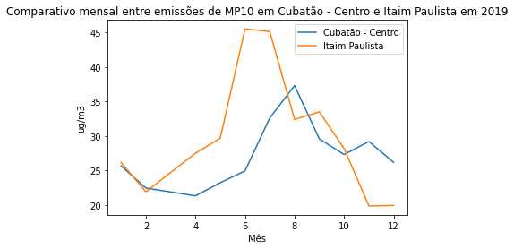

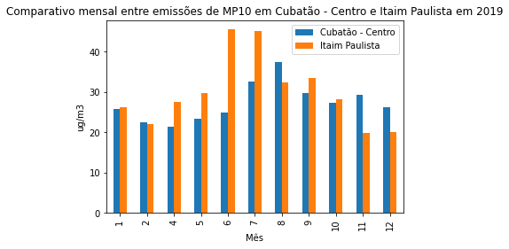

```python
from cv2 import line

xlabel_title = 'Mês'
ylabel_title = 'ug/m3'

df = pd.DataFrame(list(zip(agrupamento_estacao1_ano1_poluente1_mes.values,agrupamento_estacao2_ano1_poluente1_mes.values )),index=agrupamento_estacao2_ano1_poluente1_mes.index, columns=[nome_estacao_1,nome_estacao_2])
titulo=f"Comparativo mensal entre emissões de {poluente_1} em {nome_estacao_1} e {nome_estacao_2} em {ano1}"
ddf = df.plot(title=titulo, xlabel=xlabel_title, ylabel=ylabel_title)
df.plot.bar(title=titulo,xlabel=xlabel_title, ylabel=ylabel_title)
```

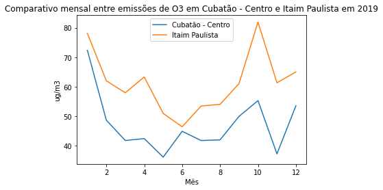

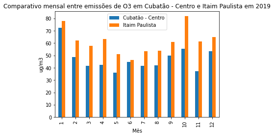

```python
df = pd.DataFrame(list(zip(agrupamento_estacao1_ano1_poluente2_mes.values,agrupamento_estacao2_ano1_poluente2_mes.values )),index=agrupamento_estacao2_ano1_poluente2_mes.index, columns=[nome_estacao_1,nome_estacao_2])
titulo=f"Comparativo mensal entre emissões de {poluente_2} em {nome_estacao_1} e {nome_estacao_2} em {ano1}"
ddf = df.plot(title=titulo, xlabel=xlabel_title, ylabel=ylabel_title)
df.plot.bar(title=titulo,xlabel=xlabel_title, ylabel=ylabel_title)
```

COMPARATIVO MENSAL DO POLUENTE 1 COM AS ESTAÇÕES 1 E 2 - ANO 2

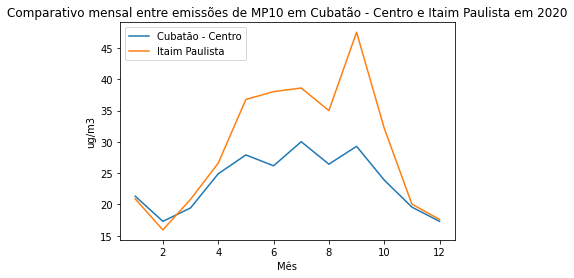

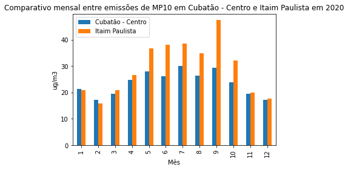

```python
df = pd.DataFrame(list(zip(agrupamento_estacao1_ano2_poluente1_mes.values,agrupamento_estacao2_ano2_poluente1_mes.values )),index=agrupamento_estacao1_ano2_poluente1_mes.index, columns=[nome_estacao_1,nome_estacao_2])
titulo=f"Comparativo mensal entre emissões de {poluente_1} em {nome_estacao_1} e {nome_estacao_2} em {ano2}"
df.plot(title=titulo, xlabel=xlabel_title, ylabel=ylabel_title)
df.plot.bar(title=titulo,xlabel=xlabel_title, ylabel=ylabel_title).legend()
```

COMPARATIVO MENSAL DO POLUNETE 2 COM AS ESTAÇÕES 1 E 2 - ANO 2

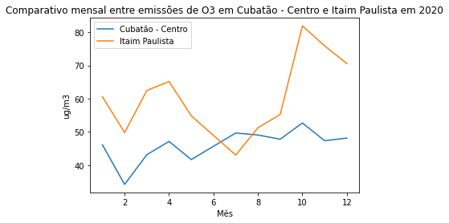

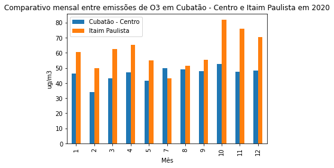

```python
df = pd.DataFrame(list(zip(agrupamento_estacao1_ano2_poluente2_mes.values,agrupamento_estacao2_ano2_poluente2_mes.values )),index=agrupamento_estacao1_ano2_poluente2_mes.index, columns=[nome_estacao_1,nome_estacao_2])
titulo=f"Comparativo mensal entre emissões de {poluente_2} em {nome_estacao_1} e {nome_estacao_2} em {ano2}"
df.plot(title=titulo, xlabel=xlabel_title, ylabel=ylabel_title)
df.plot.bar(title=titulo,xlabel=xlabel_title, ylabel=ylabel_title).legend()
```

COMPARATIVO MENSAL DO POLUENTE 1 DA ESTAÇÃO 1 ENTRE OS ANOS 1 E 2

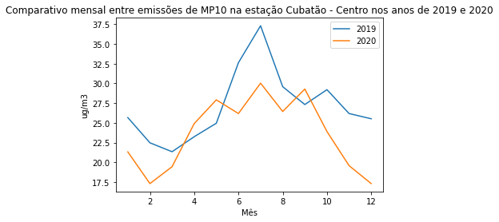

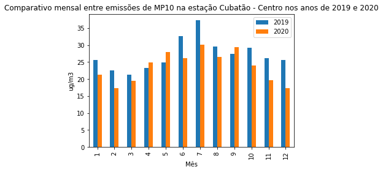

```python
df = pd.DataFrame(list(zip(agrupamento_estacao1_ano1_poluente1_mes.values,agrupamento_estacao1_ano2_poluente1_mes.values )),index=agrupamento_estacao1_ano1_poluente1_mes.index, columns=[ano1,ano2])

titulo=f"Comparativo mensal entre emissões de {poluente_1} na estação {nome_estacao_1} nos anos de {ano1} e {ano2}"
df.plot(title=titulo,xlabel=xlabel_title, ylabel=ylabel_title)
df.plot.bar(title=titulo, xlabel=xlabel_title, ylabel=ylabel_title)
```

COMPARATIVO MENSAL DO POLUENTE 1 DA ESTAÇÃO 2 ENTRE OS ANOS 1 E 2

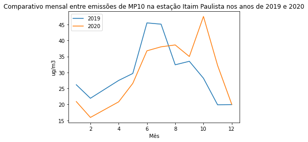

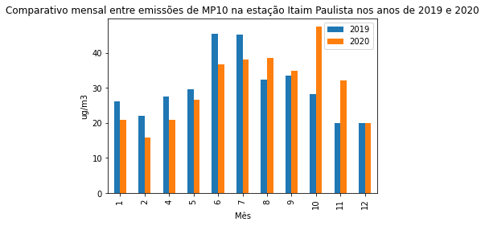

```python
df = pd.DataFrame(list(zip(agrupamento_estacao2_ano1_poluente1_mes.values,agrupamento_estacao2_ano2_poluente1_mes.values )),index=agrupamento_estacao2_ano1_poluente1_mes.index, columns=[ano1,ano2])

titulo=f"Comparativo mensal entre emissões de {poluente_1} na estação {nome_estacao_2} nos anos de {ano1} e {ano2}"
df.plot(title=titulo,xlabel=xlabel_title, ylabel=ylabel_title)
df.plot.bar(title=titulo, xlabel=xlabel_title, ylabel=ylabel_title)
```

COMPARATIVO DIÁRIO ENTRE POLUENTE 1 NA ESTAÇÃO 1 ENTRE OS ANOS 1 E 2

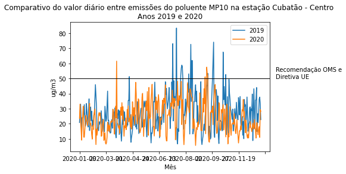

```python
df = pd.DataFrame(list(zip(agrupamento_estacao1_ano1_poluente1_dia.values,agrupamento_estacao1_ano2_poluente1_dia.values)),index=agrupamento_estacao1_ano2_poluente1_dia.index, columns=[ano1, ano2])
df[ano1] = df[ano1].astype(float)
df[ano2] = df[ano2].astype(float)
df = df[[ano1,ano2]].plot(title=f'Comparativo do valor diário entre emissões do poluente {poluente_1} na estação {nome_estacao_1} \nAnos {ano1} e {ano2}', xlabel=xlabel_title, ylabel=ylabel_title)

df.axhline(y=50, color='green', linewidth=1)
df.axhline(y=50, color='black', linewidth=1)
df.text(x=370, y=50, s='Recomendação OMS e\nDiretiva UE')
df
```

COMPARATIVO DIÁRIO ENTRE POLUENTE 2 NA ESTAÇÃO 1 ENTRE OS ANOS 1 E 2

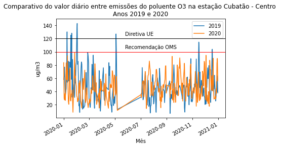

```python
df = pd.DataFrame(list(zip(agrupamento_estacao1_ano1_poluente2_dia.values,agrupamento_estacao1_ano2_poluente2_dia.values)),index=agrupamento_estacao1_ano2_poluente2_dia.index, columns=[ano1, ano2])
df[ano1] = df[ano1].astype(float)
df[ano2] = df[ano2].astype(float)
df = df[[ano1,ano2]].plot(title=f'Comparativo do valor diário entre emissões do poluente {poluente_2} na estação {nome_estacao_1} \nAnos {ano1} e {ano2}', xlabel=xlabel_title, ylabel=ylabel_title)

df.axhline(y=100, color='red', linewidth=1)
df.text(x='2020-05-25',y=105, s='Recomendação OMS')

df.axhline(y=120, color='black', linewidth=1)
df.text(x='2020-05-25',y=125, s='Diretiva UE')

df
```

COMPARATIVO DIÁRIO ENTRE POLUENTE 2 NA ESTAÇÃO 2 ENTRE OS ANOS 1 E 2

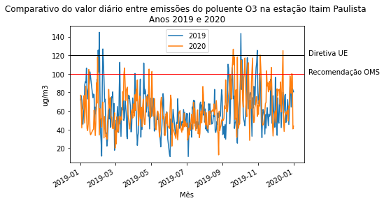

```python
df = pd.DataFrame(list(zip(agrupamento_estacao2_ano1_poluente2_dia.values,agrupamento_estacao2_ano2_poluente2_dia.values)),index=agrupamento_estacao2_ano1_poluente2_dia.index, columns=[ano1, ano2])
df[ano1] = df[ano1].astype(float)
df[ano2] = df[ano2].astype(float)
df = df[[ano1,ano2]].plot(title=f'Comparativo do valor diário entre emissões do poluente {poluente_2} na estação {nome_estacao_2} \nAnos {ano1} e {ano2}', xlabel=xlabel_title, ylabel=ylabel_title)

df.axhline(y=100, color='red', linewidth=1)
df.text(x='2020-01-25',y=100, s='Recomendação OMS')

df.axhline(y=120, color='black', linewidth=1)
df.text(x='2020-01-25',y=120, s='Diretiva UE')

df
```

COMPARATIVO DIÁRIO ENTRE POLUENTE 1 NA ESTAÇÃO 2 ENTRE OS ANOS 1 E 2

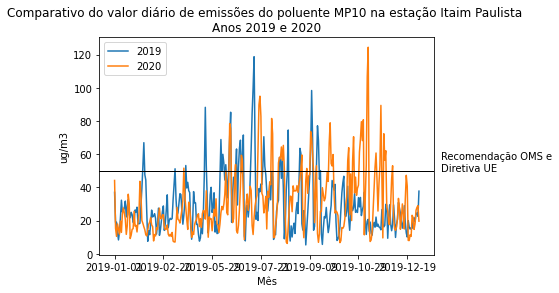

```python
df = pd.DataFrame(list(zip(agrupamento_estacao2_ano1_poluente1_dia.values,agrupamento_estacao2_ano2_poluente1_dia.values)),index=agrupamento_estacao2_ano1_poluente1_dia.index, columns=[ano1, ano2])
df[ano1] = df[ano1].astype(float)
df[ano2] = df[ano2].astype(float)
df = df[[ano1,ano2]].plot(title=f'Comparativo do valor diário de emissões do poluente {poluente_1} na estação {nome_estacao_2} \nAnos {ano1} e {ano2}', xlabel=xlabel_title, ylabel=ylabel_title)

df.axhline(y=50, color='green', linewidth=1)
df.axhline(y=50, color='black', linewidth=1)
df.text(x=335, y=50, s='Recomendação OMS e\nDiretiva UE')
df
```

COMPARATIVO ANUAL DE EMISSÃO DO POLUENTE 1 NAS ESTAÇÕES 1 E 2 NOS ANOS 1 E 2

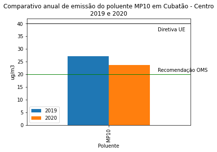

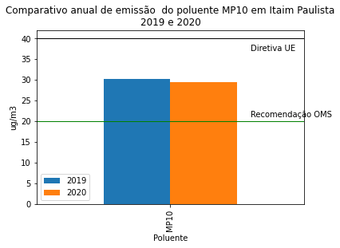

```python
df = pd.DataFrame(list(zip(agrupamento_estacao1_ano1_poluente1_ano.values,agrupamento_estacao1_ano2_poluente1_ano.values)),index=agrupamento_estacao1_ano1_poluente1_ano.index, columns=[ano1, ano2])
df[ano1] = df[ano1].astype(float)
df[ano2] = df[ano2].astype(float)
df = df[[ano1,ano2]].plot.bar(title=f"Comparativo anual de emissão do poluente {poluente_1} em {nome_estacao_1}\n{ano1} e {ano2}",ylabel=ylabel_title)

df.axhline(y=20, color='green', linewidth=1)
df.axhline(y=40, color='black', linewidth=1)
df.text(x=0.3, y=21, s='Recomendação OMS')
df.text(x=0.3, y=37, s='Diretiva UE')
df

df = pd.DataFrame(list(zip(agrupamento_estacao2_ano1_poluente1_ano.values,agrupamento_estacao2_ano2_poluente1_ano.values)),index=agrupamento_estacao2_ano2_poluente1_ano.index, columns=[ano1, ano2])
df[ano1] = df[ano1].astype(float)
df[ano2] = df[ano2].astype(float)
df = df[[ano1,ano2]].plot.bar(title=f"Comparativo anual de emissão  do poluente {poluente_1} em {nome_estacao_2}\n{ano1} e {ano2}",ylabel=ylabel_title)
df

df.axhline(y=20, color='green', linewidth=1)
df.axhline(y=40, color='black', linewidth=1)
df.text(x=0.3, y=21, s='Recomendação OMS')
df.text(x=0.3, y=37, s='Diretiva UE')
df
```

COMPARATIVO ANUAL DE EMISSÃO DO POLUENTE 2 NAS ESTAÇÕES 1 E 2 NOS ANOS 1 E 2

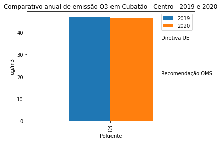

[figure not shown]

```python
df = pd.DataFrame(list(zip(agrupamento_estacao1_ano1_poluente2_ano.values,agrupamento_estacao1_ano2_poluente2_ano.values)),index=agrupamento_estacao1_ano1_poluente2_ano.index, columns=[ano1, ano2])
df[ano1] = df[ano1].astype(float)
df[ano2] = df[ano2].astype(float)
df = df[[ano1,ano2]].plot.bar(title=f"Comparativo anual de emissão {poluente_2} em {nome_estacao_1} - {ano1} e {ano2}",ylabel=ylabel_title)

df.axhline(y=20, color='green', linewidth=1)
df.axhline(y=40, color='black', linewidth=1)
df.text(x=0.3, y=21, s='Recomendação OMS')
df.text(x=0.3, y=37, s='Diretiva UE')
df


df = pd.DataFrame(list(zip(agrupamento_estacao2_ano1_poluente2_ano.values,agrupamento_estacao1_ano2_poluente2_ano.values)),index=agrupamento_estacao1_ano2_poluente2_ano.index, columns=[ano1, ano2])
df[ano1] = df[ano1].astype(float)
df[ano2] = df[ano2].astype(float)
df = df[[ano1,ano2]].plot.bar(title=f"Comparativo anual de emissão {poluente_2} em {nome_estacao_2} - {ano1} e {ano2}",ylabel=ylabel_title)

df.axhline(y=20, color='green', linewidth=1)
df.axhline(y=40, color='black', linewidth=1)
df.text(x=0.3, y=21, s='Recomendação OMS')
df.text(x=0.3, y=37, s='Diretiva UE')
df
```

QUANTIDADE DE VEZES EM QUE O VALOR LIMITE APARECE POR ANO

```python
#PM10 - 50ug/m3 até 25 vezes por ano
valor_limite = 50

acima_valor_limite_estacao1_ano1_poluente1 = agrupamento_estacao1_ano1_poluente1_dia.loc[agrupamento_estacao1_ano1_poluente1_dia.Valor >= valor_limite].count()['Valor'].astype(int)
acima_valor_limite_estacao1_ano2_poluente1 = agrupamento_estacao1_ano2_poluente1_dia.loc[agrupamento_estacao1_ano2_poluente1_dia.Valor >= valor_limite].count()['Valor'].astype(int)

acima_valor_limite_estacao2_ano1_poluente1 = agrupamento_estacao2_ano1_poluente1_dia.loc[agrupamento_estacao2_ano1_poluente1_dia.Valor >= valor_limite].count()['Valor'].astype(int)
acima_valor_limite_estacao2_ano2_poluente1 = agrupamento_estacao2_ano2_poluente1_dia.loc[agrupamento_estacao2_ano2_poluente1_dia.Valor >= valor_limite].count()['Valor'].astype(int)

df2 = pd.DataFrame({'Estação': [nome_estacao_1, nome_estacao_2],
                ano1 : (acima_valor_limite_estacao1_ano1_poluente1, acima_valor_limite_estacao2_ano1_poluente1),
                ano2 : (acima_valor_limite_estacao1_ano2_poluente1, acima_valor_limite_estacao2_ano2_poluente1)
                })
df2 = df2.set_index('Estação')

df2
```

| Estação | 2019 | 2020 |
| --- | --- | --- |
| Cubatão - Centro | 17 | 5 |
| Itaim Paulista | 42 | 51 |

```python
#O3 - 50ug/m3 até 35 vezes por ano
valor_limite = 100

acima_valor_limite_estacao1_ano1_poluente2 = agrupamento_estacao1_ano1_poluente2_dia.loc[agrupamento_estacao1_ano1_poluente2_dia.Valor >= valor_limite].count()['Valor'].astype(int)
acima_valor_limite_estacao1_ano2_poluente2 = agrupamento_estacao1_ano2_poluente2_dia.loc[agrupamento_estacao1_ano2_poluente2_dia.Valor >= valor_limite].count()['Valor'].astype(int)

acima_valor_limite_estacao2_ano1_poluente2 = agrupamento_estacao2_ano1_poluente2_dia.loc[agrupamento_estacao2_ano1_poluente2_dia.Valor >= valor_limite].count()['Valor'].astype(int)
acima_valor_limite_estacao2_ano2_poluente2 = agrupamento_estacao2_ano2_poluente2_dia.loc[agrupamento_estacao2_ano2_poluente2_dia.Valor >= valor_limite].count()['Valor'].astype(int)

df2 = pd.DataFrame({'Estação': [nome_estacao_1, nome_estacao_2],
                ano1 : (acima_valor_limite_estacao1_ano1_poluente2, acima_valor_limite_estacao2_ano1_poluente2),
                ano2 : (acima_valor_limite_estacao1_ano2_poluente2, acima_valor_limite_estacao2_ano2_poluente2)
                })
df2 = df2.set_index('Estação')

df2
```

| Estação | 2019 | 2020 |
| --- | --- | --- |
| Cubatão - Centro | 8 | 0 |
| Itaim Paulista | 20 | 25 |